# Sampling Design for Spatial Cluster Randomized Trials Under Heterogeneous Incidence

**Andrew J Walther**

Department of Biostatistics, University of North Carolina at Chapel Hill  
SUDDEN project meeting · October 29, 2026

## Outline

•BackgroundSudden unexpected death, Lenoir County pilot, spillover, and community college service area clusters

•MethodsSpillover variants, spatial autoregressive outcome model, sampling design evaluation, candidate designs vs. simple random sampling

•Simulation ResultsDesign intervention estimation accuracy on a simulated 100-cluster region

•ApplicationNorth Carolina SUD data, application of designs to NC map, accuracy, downside risk, and participation required

•DiscussionTake-home, limitations, and next steps

## Sudden unexpected death takes a large and uneven toll on working-age adults

### Nationally

- **Sudden unexpected death (SUD):** an unexpected natural death outside the hospital in a working-age adult
- About **49 per 100,000 men and 22 per 100,000 women** aged 20–64 each year (US estimate from SUDDEN adjudication in Wake County)
- About **2 million years of life lost**, **10%** of all-cause years of life lost at these ages, and about $51 billion in lifetime productivity loss

Mirzaei et al., Medical Care 2019; Gan et al., J Gen Intern Med 2019.

### In North Carolina, 2018–2021

23,523  
presumed SUD deaths among adults aged 18–64, from death certificates

84 → 101  
statewide deaths per 100,000 per year (corrected counts), rising each year from 2018 to 2021

Higher in rural counties, in 2014 about 100 per 100,000 in highly rural NC counties against 68 in highly urban ones (Gan et al.)

## Dr. Simpson’s Lenoir County pilot is the starting point for a statewide trial

**SUD as a social problem**SUDDEN findings show sudden death tracks access to care, income and rurality, so prevention has to reach communities, not only hospitals

→

**Lenoir County pilot idea**Teach SUD prevention through Lenoir Community College’s workforce-development and disaster-response training (Lenoir, Greene and Jones counties), where Dr. Simpson notes SUD rates spike after flooding

→

**Trainees (to confirm)**Students and staff in those programs, possibly including EMS and healthcare trainees; students earn credit, and the response goes beyond getting people to the hospital

→

**After the pilot**Share what works with the other counties and all 58 community colleges; colleges talk to each other, so training can spill over

→

**This project**Which colleges should get it first, and how should incidence guide that choice?

- The pilot is delivered **county-wide through a college**, not by census tract, so the natural unit is a college’s service area
- Dr. Simpson expects early effects in **process measures** (taking medicine, timely clinic visits), not SUD rates; for the design study we assume a trainee **education score**
- A statewide trial treats some colleges and holds others as controls, and colleges talk to each other, so training can spread
- Our proposal uses past SUD incidence to guide **where** the program goes while keeping the trial randomized

## When a program reaches neighbors, a simple comparison can miss its effect

### Bed nets, northern Ghana

Children living near households with insecticide-treated bed nets had lower mortality, even when their own household had none.

### School deworming, western Kenya

Untreated children attending schools near treated schools had fewer worm infections.

Spillover means that treating one group changes outcomes in the groups next to it

- A trial that compares treated with untreated clusters assumes each cluster’s outcome depends only on its own treatment
- With spillover, untreated neighbors look better than they would have, so the treated-versus-control gap understates the effect

Binka et al., Trop Med Int Health 1998; Miguel and Kremer, Econometrica 2004.

## Analysis methods exist, but guidance on which clusters to treat is thin

### After the trial (analysis)

- Spatial models separate a program’s direct effect from the effect of treated neighbors
- They need a trial designed to give them that contrast

### Before the trial (design)

- Which clusters should be treated?
- Options serve different goals (balance a covariate, vary the treated share by region, keep treated clusters apart)
- Few studies compare them under spillover and uneven incidence together

**Our earlier work** (BMC Medical Research Methodology, 2026) compared random and stratified allocation on small grids. This project adds uneven incidence, a larger study region, more designs and the real North Carolina map.

## The trial’s clusters are North Carolina’s 58 community college service areas

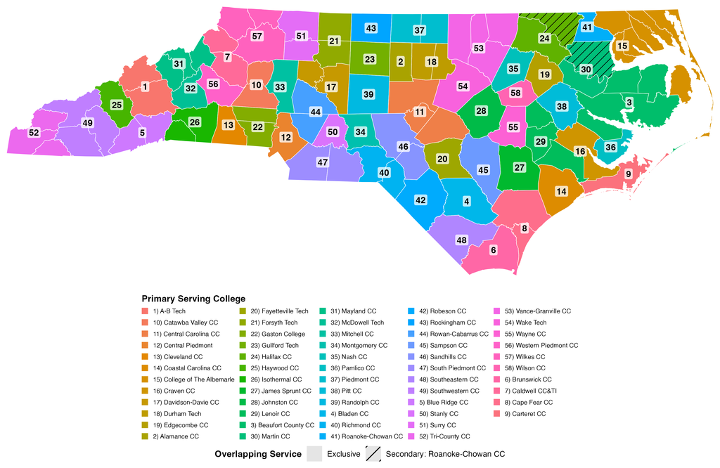

**100 counties**Each assigned to its primary serving college (state list of colleges and the counties they serve)

**58 service areas**31 colleges serve one county, 18 serve two, 9 serve three to seven

**Shared counties**Bertie and Northampton (hatched) also lie in Roanoke-Chowan’s network; each is assigned to its primary college

**Neighbors**Two service areas are neighbors if they share a border or a corner (legal boundaries, including across water)

The trial measures an education outcome, not SUD deaths. Incidence guides allocation only.

## Spillover can reach only the untreated colleges, or every college

Spillover to controls only  
untreated colleges gain

[figure not shown]

Spillover to both arms  
treated and untreated colleges gain

[figure not shown]

Treated college Control college Gains from treated neighbors (more treated neighbors, larger gain)

- **Controls only** is classic contamination, in which untreated colleges learn from treated neighbors
- **Both arms** means treated colleges also gain from treated neighbors, for example through shared trainings
- Which one holds is a judgment about how the program spreads, and the best design depends on it

## One outcome model links treatment, spillover and neighbors

$$Y = (I - \rho W)^{-1}\left[\,\tau Z + S(Z) + \beta X + \epsilon\,\right], \qquad \epsilon \sim N(0, I)$$

Spillover to both arms $S(Z) = \gamma\, WZ$ Spillover to controls only $S(Z) = \gamma\,(1 - Z) \circ WZ$

$Y$Outcome of each cluster (in the application, a college’s mean education score) $Z$Treatment indicator, 1 if the cluster is treated and 0 if control $W$Neighbor matrix. Under queen contiguity two clusters are neighbors if they share an edge or a corner. Each row sums to 1, so $(WZ)_i$ is the share of cluster $i$’s neighbors that are treated $\tau$Direct effect of a cluster’s own treatment before outcomes spread between neighbors through $(I-\rho W)^{-1}$ (not a total effect), in standard deviations of the noise $\epsilon$; the quantity we estimate $\rho$Spatial dependence, how much a cluster’s outcome follows its neighbors’ outcomes (0 to 0.5) $S(Z)$Spillover, the gain from treated neighbors, in one of the two regimes above $(I-\rho W)^{-1}$Spreads every cluster’s outcome to its neighbors, neighbors’ neighbors and so on ($I$ is the identity matrix) $\gamma$Spillover magnitude, the gain when every neighbor is treated (0.5 to 0.8 on the grid; 50% or 80% of $\tau$ in the power analysis) $\beta$How strongly incidence shifts the outcome. $\beta = 1$ on the grid; for the NC education outcome $\beta = 0$ (primary), with $\beta = 1$ only as a hypothetical sensitivity $X$Cluster incidence on a 0 to 1 scale (simulated on the grid; in NC, the rank of the observed SUD rate scaled to 0 to 1, used only when $\beta = 1$) $\epsilon$Independent standard normal noise in each cluster’s outcome $\circ$Elementwise product, so $(1-Z)\circ WZ$ is zero for treated clusters

## We judge each design by its average error, its intervals and its worst allocations

We estimate the program’s effect $\tau$ with a spatial model that allows for spillover (a spatial lag model fitted by maximum likelihood, including the true spillover term), and repeat the trial thousands of times in simulation.

### Mean squared error (MSE)

The average of $(\hat\tau - \tau)^2$ over simulated trials. It combines bias and imprecision. **Lower is better.**

### Coverage

The share of 95% confidence intervals that contain the true $\tau$. It should be close to 95% (we use a small-sample corrected interval).

### Allocation risk

A trial gets **one** allocation. How bad are the worst ones? For each allocation $a$, $m(a)$ is its expected squared error; we report the **mean of the worst 10%** of allocations.

Every design is compared with **simple random sampling (SRS)**, a completely random choice of half the clusters, the usual default. A ratio to SRS below 1 means lower error than SRS.

## Six designs and simple random sampling choose treated clusters differently

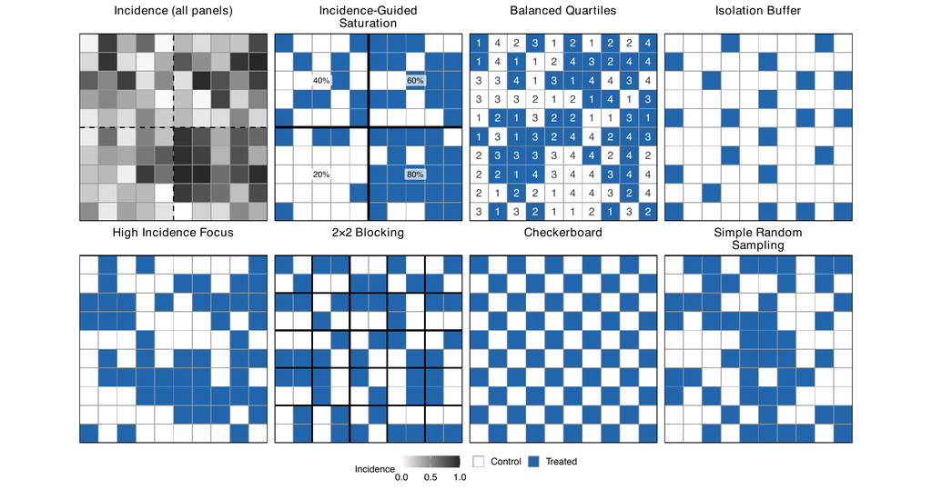

One example assignment per design on the 100-cluster grid (blue, treated; white, control). Top-left panel is the incidence surface used by every example (darker is higher). Percentages give each quadrant’s treated share; numbers in Balanced Quartiles give each cluster’s incidence quartile.

**Target incidence** High Incidence Focus · **Balance incidence** Balanced Quartiles · **Separate or alternate** Checkerboard, Isolation Buffer, 2×2 Blocking · **Vary the treated share by region** Incidence-Guided Saturation (80, 60, 40, 20%)

## The grid study varied every condition we cannot pin down in advance

| Condition | Values |
| --- | --- |
| Study region | 10 × 10 grid of 100 clusters; queen neighbors (rook, edges only, as a sensitivity) |
| How incidence varies across space | Independent, spatially smooth (2 strengths), Poisson death counts (2 strengths) |
| Spatial dependence of outcomes, $\rho$ | 0, 0.01, 0.2, 0.5 |
| Spillover magnitude, $\gamma$ | 0.5, 0.6, 0.7, 0.8 |
| Spillover regime | Controls only, both arms |
| Treatment effect, $\tau$ | 0.8, 1, 1.5, 2, 3 (results shown at $\tau = 1$) |
| Replication | 10 incidence maps × 25 allocations and outcomes = 250 simulated trials per scenario |

A regular grid lets us vary conditions systematically before moving to the real map.

## On the grid, the spillover regime decides which design wins

| Design | Spillover to controls only | Spillover to both arms |
| --- | --- | --- |
| Incidence-Guided Saturation | 0.63 | 1.08 |
| Isolation Buffer | 0.74 | 3.80 |
| Balanced Quartiles | 1.02 | 0.99 |
| High Incidence Focus | 1.53 | 3.82 |
| 2×2 Blocking | 2.68 | 1.47 |
| Checkerboard | 9.84 | 1.47 |
| Simple Random Sampling (MSE) | 0.215 | 0.042 |

MSE relative to SRS, grid, queen neighbors, $\tau = 1$; blue lower than SRS, orange higher, grey not distinguishable from SRS (paired 95% interval includes 1).

**Controls only**  
Incidence-Guided Saturation had **37% lower error** than SRS (MSE 0.136 vs 0.215)

**Both arms**  
No design beat SRS. Balanced Quartiles matched it; Incidence-Guided Saturation was 8% higher

Checkerboard and 2×2 Blocking were worse than SRS in both regimes, and far worse under controls only

Coverage of 95% intervals was 94–95% for every design.

## SUD deaths were identified from death certificates with a validated algorithm

**412,514** North Carolina deaths, 2018–2021

→

Exclude ages under 18 or over 64

↓

**111,665** deaths among adults aged 18–64

→

Exclude deaths in a hospital, hospice or nursing home

↓

Out-of-hospital deaths

→

Exclude suicide, homicide and accidents

↓

Natural out-of-hospital deaths

→

Exclude expected deaths from cancer

↓

**23,523** presumed sudden unexpected deaths

- The algorithm (Gan et al. 2019) was **validated against SUDDEN physician adjudication** of health records, EMS and death-certificate reports (as described in Habib 2026)
- Prepared by Ashkan Habib by county and year; rates use SEER population aged 18–64 (25.6 million person-years)
- Steps follow Gan et al. (2014 data, 83,509 certificates → 4,278 SUD); the statewide counts add a few exclusion rules (Habib 2026) and keep heart-failure deaths (excluding them gave 21,147)

## We built the application study in six steps, fixing every rule before looking at results

**1 · Data**County-year SUD deaths and SEER population aged 18–64, 2018–2021

→

**2 · Clusters**100 counties into 58 college service areas; neighbors share a border or a corner

→

**3 · Incidence**Yearly SUD rate per 100,000 for each service area; each year a separate planning input

→

**4 · Designs**Each rule adapted to the map: four fixed regions, spatial blocks, a map Checkerboard

→

**5 · Simulate**Education scores from the outcome model with $\beta = 0$, $\tau = 1$; 100 allocations × 100 outcomes per setting

→

**6 · Evaluate**Error, coverage, risk of an unlucky allocation, and power with 15 to 58 participating colleges

- Incidence is **held fixed** at the observed rates; only the allocations and the education scores are simulated
- Spatial dependence $\rho$ = 0, 0.2, 0.5 and spillover $\gamma$ = 0.5, 0.8, in both regimes
- 7.6 million simulated trials; every setting met its precision targets with no estimation failures
- Sensitivity analyses: $\beta = 1$, rook neighbors, other region orderings, other spatial models

## SUD incidence is uneven across North Carolina and shifts from year to year

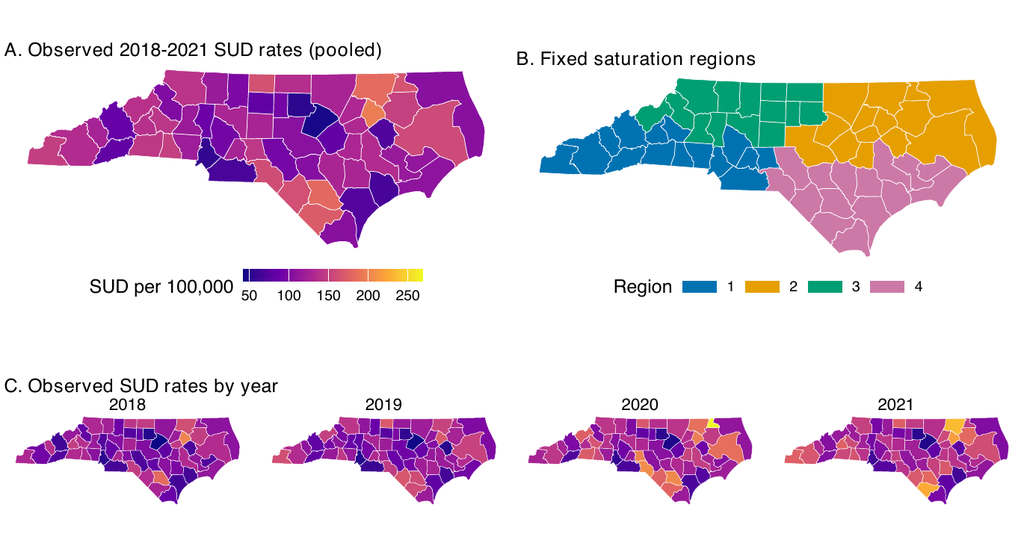

Panel A, SUD deaths per 100,000 adults aged 18–64, pooled 2018–2021, by college service area. Panel B, the four fixed regions used by Incidence-Guided Saturation. Panel C, yearly rates on the same color scale.

- **23,523 deaths** over 25.6 million person-years (ages 18–64), corrected county death-certificate counts (Gan et al. case definition)
- Each year is a separate planning input; incidence decides who is treated, not the education outcome

## Each design was adapted to the map before we looked at any results

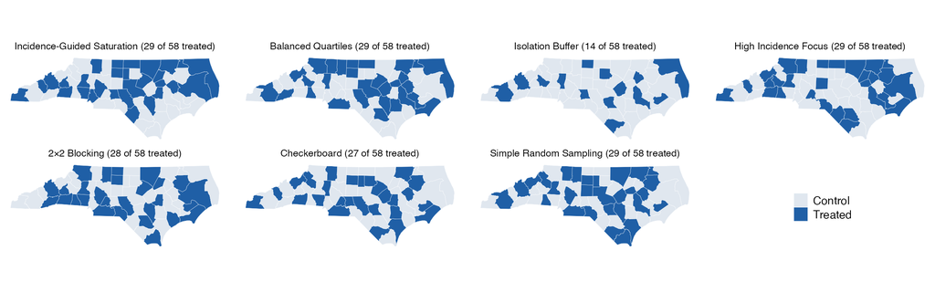

One example allocation per design on the 58-college map, 2018 incidence (Isolation Buffer treats 14 here, about 16 on average). Checkerboard becomes an alternating pattern on the irregular map; 2×2 Blocking becomes spatial blocking of 14 groups of nearby colleges; Incidence-Guided Saturation uses the four fixed regions.

- Most designs treat **29 of 58** colleges. Checkerboard treats 27, spatial blocking 27–31, and Isolation Buffer only about 16
- We report these budgets rather than force them to be equal

## Treating half the colleges does not always reach half the population

| Design | Colleges treated (of 58) | 2018 | 2019 | 2020 | 2021 |
| --- | --- | --- | --- | --- | --- |
| Incidence-Guided Saturation | 29 | 53% | 45% | 48% | 52% |
| Balanced Quartiles | 29 | 49% | 50% | 51% | 50% |
| Isolation Buffer | about 16 | 27% | 27% | 27% | 27% |
| High Incidence Focus | 29 | 22% | 24% | 23% | 22% |
| 2×2 Blocking (spatial blocks) | 28 / 31 / 27 / 29 | 50% | 55% | 48% | 50% |
| Checkerboard | 27 | 50% | 50% | 50% | 51% |
| Simple Random Sampling | 29 | 50% | 50% | 50% | 50% |

Average share of North Carolina’s adults aged 18–64 living in treated service areas, by planning year. Geographic reach, not the number of professionals trained.

High Incidence Focus treats half the colleges but reaches under a quarter of the working-age population, since the highest-rate service areas are small.

## With 58 colleges, Incidence-Guided Saturation beats SRS under spillover to controls only

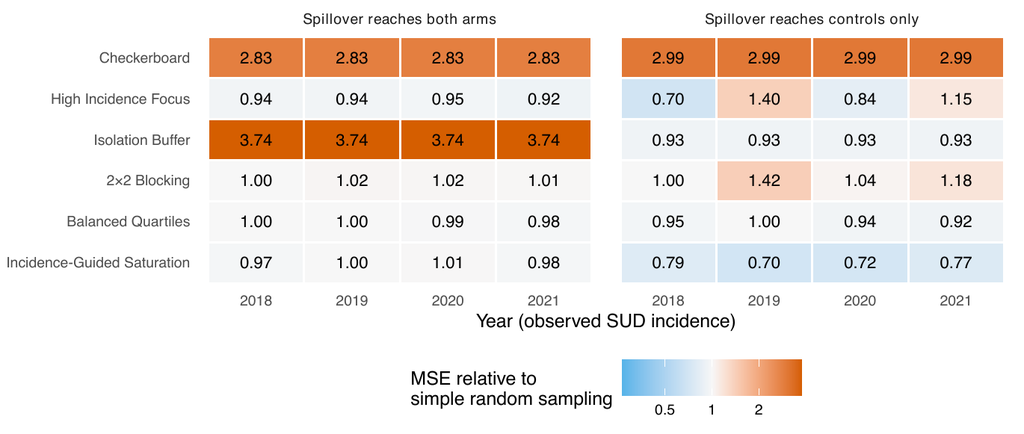

Mean MSE divided by SRS’s in the same year and regime (each cell averages six settings of $\rho$ and $\gamma$). Blue is lower error than SRS, orange higher. Years share one map and several designs share simulations across years, so years are not independent replications.

- **Both arms:** SRS, Balanced Quartiles and Incidence-Guided Saturation are within about 3% of each other
- Checkerboard is about 3 times SRS’s error in both regimes; Isolation Buffer 3.7 times under both arms
- **Controls only:** Incidence-Guided Saturation had **21–30% lower error** than SRS in every year
- High Incidence Focus swings from 0.70 to 1.40 times SRS as its treated colleges change with each year’s incidence

## Under controls-only spillover, Incidence-Guided Saturation also lowers the risk of a bad draw

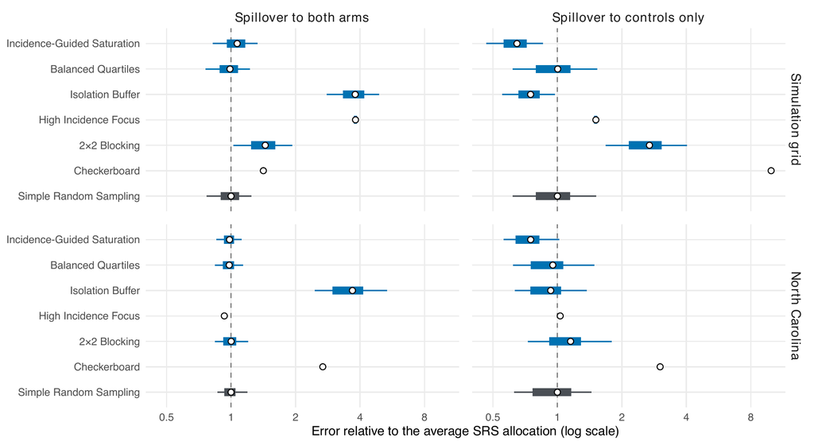

Each bar is the spread of error across one design’s possible allocations, relative to SRS’s average (thin line 5th–95th percentile, thick bar 25th–75th, circle the mean); top, grid; bottom, NC. Dark grey marks SRS. Under controls only, Incidence-Guided Saturation’s worst 10% of allocations had **21–43% lower error** than SRS’s worst 10% in NC (grid 0.19 vs 0.35); under both arms the differences are small and mostly simulation noise.

## About 36 colleges give 80% power at one SD when spillover reaches every college

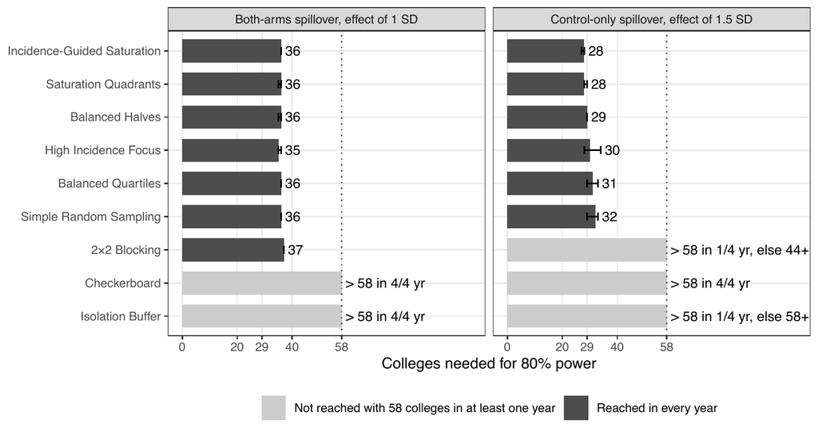

Colleges needed for 80% power (corrected $t$ test, 5% false-positive rate), random volunteering, $\rho = 0.5$, spillover from a fully treated neighborhood equal to 80% of the direct effect. Effects are in college-level standard deviations (SD). Bars, mean over 2018–2021; whiskers, range; grey, not reached with 58 colleges in at least one year. Saturation Quadrants and Balanced Halves are backup variants.

- Counts are **participating** colleges, about half treated; one college-level SD ≈ 0.3 SD per professional (25 assessed, ICC 0.05)
- **Both arms, 1 SD:** 35–37 participating colleges with any design except Checkerboard and Isolation Buffer
- **Controls only:** no design reaches 80% power at 1 SD even with all 58; at 1.5 SD, Incidence-Guided Saturation needs 28 colleges against 32 for SRS

## If fewer colleges join, Incidence-Guided Saturation’s advantage shrinks

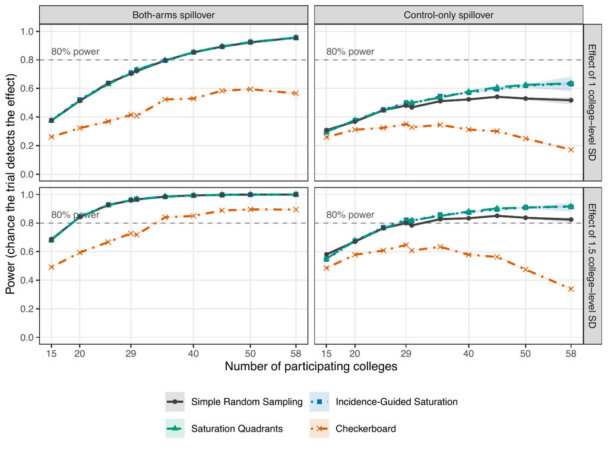

| Participating colleges | Incidence-Guided Saturation error vs SRS (controls only) |
| --- | --- |
| 58 | 22% lower |
| 40 | 9% lower |
| 29 | 5% lower |
| 20 | about 1% lower |

- Under controls only, SRS power stalls past about 40 colleges (Incidence-Guided Saturation keeps rising slowly), since nearly every control then has treated neighbors
- If higher-incidence colleges are more likely to volunteer, the advantage is 2% or less at 20–29 colleges

Figure, $\rho = 0.5$, spillover 80% of the effect (Saturation Quadrants is a backup variant). Table, $\tau = 1$, averaged over $\rho = 0, 0.5$ and spillover 50% or 80% of the effect; the 21–30% on the accuracy slide uses the main settings.

## A one-SD college effect is a modest effect for each trained professional

A college score averages $m$ professionals. With intraclass correlation ICC (share of score variance between colleges), the college-level noise SD ($\epsilon$), in individual SD units, is
$$\sigma_c = \sqrt{\text{ICC} + (1 - \text{ICC})/m}$$
so a college effect of $\tau$ SDs is an individual effect of $d = \tau\,\sigma_c$.

With **25 professionals per college** and **ICC = 0.05**, $\sigma_c \approx 0.30$, so a **one-SD college effect is about 0.3 SD per professional**

| Professionals per college | 29 participating colleges | 58 participating colleges |
| --- | --- | --- |
| 10 | 0.51 | 0.82 |
| 25 | 0.71 | 0.96 |
| 50 | 0.80 | 0.98 |

Power with SRS for an individual effect of $d = 0.3$, ICC = 0.05, spillover to both arms. Under controls only, power with all 58 is about 0.53 (SRS) to 0.64 (Incidence-Guided Saturation).

Your input on **how many professionals each college trains** and **how much scores vary between colleges** would sharpen these (pilot scores would tell us the second).

## Incidence-Guided Saturation was a reasonable middle ground with limited downside

Incidence-Guided Saturation gained the most under controls-only spillover, at a small cost under both arms

### Spillover to controls only (untreated colleges gain)

Lowest or near-lowest error with all colleges taking part (21–30% below SRS in NC, 37% on the grid), a lower risk of an unlucky allocation, and the most treatment in the highest-rate region (a small shift on the NC map, where regions are similar). Even with all 58 colleges, power for a one-SD effect is only about 53% (SRS) to 64%

### Spillover to both arms (every college gains)

Close to SRS (within 8% on the grid and 3% in NC), so little is lost. About **36 participating colleges** give 80% power for a one-SD college effect (about 0.3 SD per professional) under our assumptions

- Balanced Quartiles stayed close to SRS in both regimes; Checkerboard and 2×2 Blocking never improved on SRS; High Incidence Focus varied by year under controls only and is not randomized
- Its advantage is largest when most colleges join; the right choice still depends on the spillover we expect

## Key assumptions remain, and the next step is to define the endpoint and size the trial

### Limitations

- Our analysis assumed we know how spillover works; if the analysis ignores spillover, every design underestimates the effect
- Planning incidence was treated as exact and fixed
- Neighboring service areas stand in for how professionals actually communicate
- Designs treat different numbers of colleges, so this is not a comparison at equal cost
- This evaluates trial designs, not the program’s effect on SUD

### Next steps

- Define the education endpoint, eligible professionals and budgets
- Choose the plausible spillover regime and contact network with this group, and whether a staggered rollout is feasible
- Sample size for the agreed effect size, participation and intraclass correlation
- Later, a design for an SUD-incidence endpoint (a count outcome)

The regime-specific guidance held under CAR models, a Bayesian spatial lag model and rook neighbors, except a misspecified Bayesian CAR fit (backup slides).

## Thank you!

#### Advisor

Feng-Chang Lin

#### Collaborators

Ross J. Simpson, Jr. · Ashkan Habib

#### Data

Corrected NC county SUD counts (A. Habib), UNC IRB protocol 14-2036; SEER population estimates

#### Papers

Design study manuscript in preparation for *Clinical Trials*  
Earlier work, Walther et al., *BMC Medical Research Methodology* (2026)

Questions welcome

awalther@unc.edu

## Backup · Questions we could put to the group

1. **How does the program spread?** Mainly to untreated colleges nearby, or to every college, treated ones included? Is a shared border the right idea of “neighbor”?
2. **What is the education outcome**, when would it be measured, and what improvement would be worth detecting?
3. **How many colleges and professionals?** How many colleges would join (and would higher-incidence ones be keener), how many professionals each would train, and would control colleges accept a delayed start?
4. **Target rates or deaths?** Should allocation favor high-rate areas or the areas where most deaths occur?
5. **Who is trained, and who is assessed?** Students and staff in workforce-development and disaster-response programs, EMS or other healthcare trainees? And in control colleges, who is measured? (for Dr. Simpson)

## Backup · Incidence guidance sends more treatment to high-burden regions only where regions differ

| Design (NC, mean over years) | Treated share of total incidence (rate-weighted) | Share of SUD deaths in treated areas |
| --- | --- | --- |
| High Incidence Focus | 62.2% | 35.4% |
| Incidence-Guided Saturation | 51.1% | 49.2% |
| Saturation Quadrants (same rule, random region order) | 50.4% | 49.6% |

- North Carolina’s four regions have similar average incidence (mean ranks 24–34 of 58), so guidance shifts the rate share by less than one point here
- On the grid, where regions differed more, guidance raised the treated share by 2–3 points while **matching the accuracy of random-order saturation**
- High-rate service areas are small, so targeting rates reaches fewer deaths

## Backup · Full rules for each design on the grid and the NC map

| Design | Grid (100 clusters) | NC (58 colleges) |
| --- | --- | --- |
| Checkerboard | Alternating pattern; no two clusters sharing an edge in the same arm (50 treated) | Deterministic map version: visits colleges from most to fewest neighbors, gives each the arm less common among its assigned neighbors (27) |
| High Incidence Focus | The 50 highest-incidence clusters, ties broken at random | The 29 highest observed rates |
| Isolation Buffer | Add clusters at random from those with no treated neighbor until none remain (about 21 with queen neighbors) | Same rule on the NC neighbor graph (about 16) |
| 2×2 Blocking | 25 blocks of 2×2; treat 2 at random in each (50) | Spatial blocking: 14 groups by $k$-means on location, incidence rank and log-population; treat a random half of each, rounded (27–31 by year) |
| Balanced Quartiles | Treat half of each incidence-rank quartile (50) | Same, with observed rates (29) |
| Incidence-Guided Saturation | Treat 80, 60, 40, 20% of the four 5×5 quadrants, ordered by mean incidence (50) | Same, four fixed regions (chosen from 250 $k$-means partitions for compactness and balance), ordered by mean rank of observed rates (29) |
| Simple Random Sampling | A completely random half (50) | Same (29) |
| *Saturation Quadrants* | *Variant: same saturations, quadrants in random order* | *Same, four fixed regions* |
| *Balanced Halves* | *Variant: treat half of each incidence half* | *Same, with observed rates* |

## Backup · Grid benchmark with absolute error and coverage

| Design | Both arms MSE | Both arms Coverage | Both arms Ratio to SRS (95% CI) | Controls only MSE | Controls only Coverage | Controls only Ratio to SRS (95% CI) |
| --- | --- | --- | --- | --- | --- | --- |
| Checkerboard | 0.0624 | 0.948 | 1.47 (1.44, 1.51) | 2.1114 | 0.951 | 9.84 (9.65, 10.03) |
| High Incidence Focus | 0.1617 | 0.950 | 3.82 (3.71, 3.92) | 0.3292 | 0.945 | 1.53 (1.45, 1.62) |
| Isolation Buffer | 0.1608 | 0.948 | 3.80 (3.72, 3.87) | 0.1595 | 0.950 | 0.74 (0.72, 0.77) |
| 2×2 Blocking | 0.0623 | 0.947 | 1.47 (1.44, 1.50) | 0.5761 | 0.950 | 2.68 (2.62, 2.74) |
| Balanced Quartiles | 0.0421 | 0.949 | 0.99 (0.97, 1.02) | 0.2195 | 0.942 | 1.02 (1.00, 1.05) |
| Incidence-Guided Saturation | 0.0459 | 0.949 | 1.08 (1.06, 1.11) | 0.1355 | 0.945 | 0.63 (0.61, 0.65) |
| Simple Random Sampling | 0.0424 | 0.950 | N/A | 0.2146 | 0.946 | N/A |

Queen neighbors, $\tau = 1$; each entry averages 80 scenarios (5 incidence configurations × 4 values of $\rho$ × 4 of $\gamma$). Coverage uses the $t$ interval with degrees-of-freedom-corrected SE. Ratio CI: paired over the 50 independent configuration-by-surface units, no multiplicity adjustment.

## Backup · The grid ordering holds in every incidence configuration

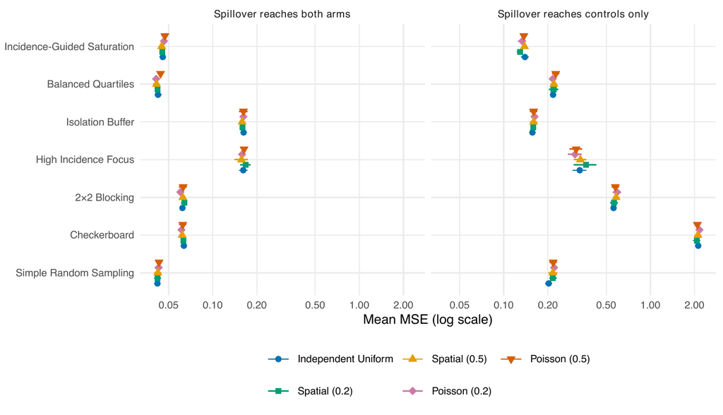

Grid mean MSE at $\tau = 1$, queen neighbors, by incidence configuration (parentheses give incidence dependence $\rho_X$), log scale. Horizontal lines are 95% Monte Carlo intervals over ten incidence surfaces.

## Backup · Under rook neighbors, Checkerboard cannot estimate the effect

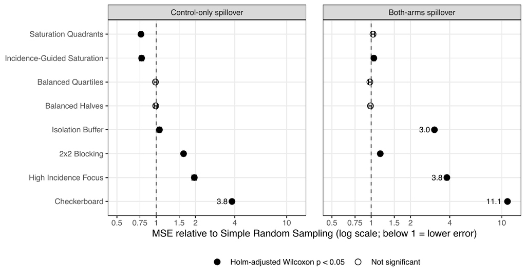

- Rook neighbors share an edge only. Under rook, Checkerboard gives $WZ = 1 - Z$, so exposure cannot be separated from treatment, $\tau$ is **not identified**, and the estimate centers on $\tau - \gamma$ (coverage 0.16)
- Under queen, Checkerboard is identified but imprecise, since interior clusters all have half their neighbors treated
- Other designs keep the regime-specific pattern, with differences. Under controls only the saturation advantage is smaller (23–24% lower MSE than SRS, against 37% under queen), and Isolation Buffer loses its advantage (5.8% higher than SRS). Pooled MSE, Incidence-Guided Saturation 0.072 and Balanced Quartiles 0.084 lead

## Backup · Mean and worst-decile error relative to SRS

| Design | Grid Both arms Mean | Grid Both arms Worst 10% | Grid Controls only Mean | Grid Controls only Worst 10% | NC application Both arms Mean | NC application Both arms Worst 10% | NC application Controls only Mean | NC application Controls only Worst 10% |
| --- | --- | --- | --- | --- | --- | --- | --- | --- |
| Checkerboard | 1.41 | 1.11 | 9.94 | 6.22 | 2.68 | 2.20 | 3.02 | 1.88 |
| High Incidence Focus | 3.81 | 3.05 | 1.51 | 0.96 | 0.93 | 0.76 | 1.03 | 0.64 |
| Saturation Quadrants | 1.06 | 1.06 | 0.62 | 0.54 | 0.99 | 0.94 | 0.73 | 0.64 |
| Isolation Buffer | 3.80 | 3.97 | 0.75 | 0.62 | 3.69 | 4.75 | 0.93 | 0.91 |
| 2×2 Blocking | 1.44 | 1.57 | 2.69 | 2.64 | 1.00 | 1.02 | 1.15 | 1.18 |
| Balanced Quartiles | 0.99 | 0.99 | 1.00 | 1.01 | 0.98 | 0.96 | 0.95 | 1.01 |
| Balanced Halves | 0.99 | 0.99 | 1.01 | 1.01 | 0.98 | 0.96 | 0.97 | 0.99 |
| Incidence-Guided Saturation | 1.07 | 1.07 | 0.65 | 0.55 | 0.98 | 0.93 | 0.75 | 0.68 |

Each column averages over settings first, then divides by SRS’s average for the same quantity (mean by SRS mean, worst 10% by SRS worst-10% mean). The main slide’s 21–43% is the range across the eight NC year × $\rho$ settings. Grid: queen, $\tau = 1$, all 50 configuration-by-surface units at $\rho \in \{0, 0.5\}$, $\gamma \in \{0.5, 0.8\}$. NC: $\rho \in \{0, 0.5\}$, $\gamma = 0.8$, 400 outcomes per allocation, 2018–2021. A design with one allocation has worst-decile mean equal to its mean.

## Backup · Population reached by each design, by year

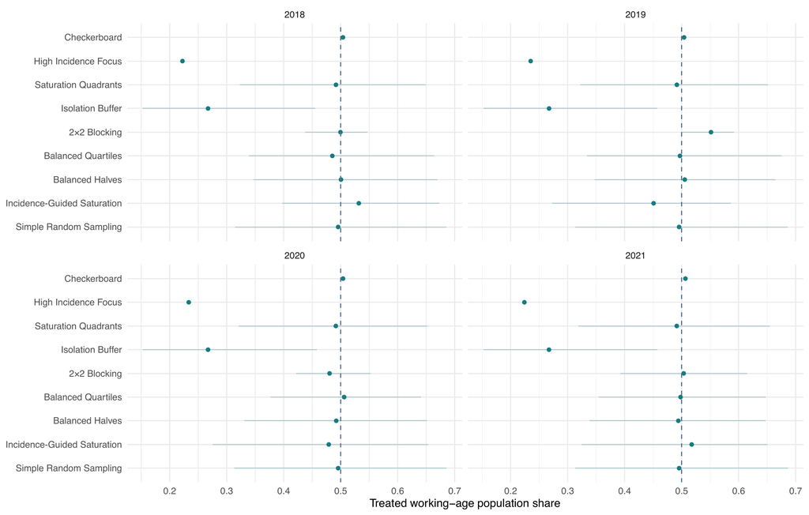

Share of NC adults aged 18–64 living in treated service areas; points are means over sampled allocations and lines show the spread across allocations. Includes the two variants.

## Backup · If incidence did shift education scores ($\beta = 1$)

- A hypothetical check adds incidence rank to the outcome ($\beta = 1$) and adjusted for in the analysis
- **High Incidence Focus** error rose about **3.7–4.4-fold** under both arms and **1.4–2.5-fold** under controls only
- Aligning treatment with incidence leaves little independent information about $\tau$ once incidence is adjusted for
- Randomized designs were little affected; the regime-specific guidance is unchanged
- Not an empirical claim that SUD incidence predicts education scores; the baseline and the adjustment were added together

## Backup · Leaving the spillover term out of the analysis biases every design

- Grid sensitivity: fit $Y \sim Z$ (plus incidence) without the spillover term
- Every identified design **underestimated** $\tau$: bias $-0.12$ to $-0.40$, coverage 54–91%, at $\tau = 1$ (queen and rook)
- Some designs had *lower* MSE than under the correct model, since less variance outweighed the bias, so low MSE alone does not mean valid inference
- Incidence-Guided Saturation still had the lowest MSE under both neighbor types

A good allocation does not replace an analysis that models spillover.

## Backup · The corrected interval restores 95% coverage

| Design | Grid queen Wald / $t$ | NC both Wald / $t$ | NC controls Wald / $t$ |
| --- | --- | --- | --- |
| Incidence-Guided Saturation | 93.7 / 94.7 | 93.5 / 94.9 | 92.7 / 94.2 |
| Balanced Quartiles | 93.6 / 94.6 | 93.3 / 94.8 | 92.9 / 94.4 |
| Isolation Buffer | 93.9 / 94.9 | 93.2 / 94.7 | 93.1 / 94.7 |
| High Incidence Focus | 93.8 / 94.8 | 93.4 / 94.9 | 93.1 / 94.6 |
| 2×2 Blocking | 93.9 / 94.8 | 93.2 / 94.7 | 92.9 / 94.4 |
| Checkerboard | 94.1 / 95.0 | 93.6 / 94.9 | 93.4 / 94.8 |
| Simple Random Sampling | 93.8 / 94.8 | 93.2 / 94.7 | 92.9 / 94.5 |

Coverage (%) of 95% intervals. Wald: $\hat\tau \pm 1.96\,\widehat{\rm SE}$. Corrected: $\hat\tau \pm t_{0.975,N-p}\,\widehat{\rm SE}\sqrt{N/(N-p)}$, $N$ clusters, $p$ coefficients including $\rho$.

| Colleges | Wald test size | Corrected size |
| --- | --- | --- |
| 15 | 11.1–12.8% | 4.4–5.4% |
| 29 | 8.3–8.8% | 5.0–5.5% |
| 58 | 6.3–7.0% | 5.0–5.5% |

False-positive rate at $\tau = 0$ across designs (NC partial participation). Corrected-interval coverage at $\tau = 1$ was 94.0–95.6% at every number of colleges.

## Backup · Power for individual effects by training size and intraclass correlation

| $m$ | ICC | $\sigma_c$ | Both arms 29 colleges $d$=0.2 | Both arms 29 colleges $d$=0.3 | Both arms 58 colleges $d$=0.2 | Both arms 58 colleges $d$=0.3 | Controls only 29 colleges $d$=0.2 | Controls only 29 colleges $d$=0.3 | Controls only 58 colleges $d$=0.2 | Controls only 58 colleges $d$=0.3 |
| --- | --- | --- | --- | --- | --- | --- | --- | --- | --- | --- |
| 10 | 0.01 | 0.330 | 0.33 | 0.62 | 0.61 | 0.90 | 0.22 | 0.41 | 0.24 | 0.45 |
| 10 | 0.05 | 0.381 | 0.27 | 0.51 | 0.50 | 0.82 | 0.18 | 0.33 | 0.20 | 0.36 |
| 10 | 0.10 | 0.436 | 0.22 | 0.41 | 0.40 | 0.71 | 0.15 | 0.27 | 0.17 | 0.30 |
| 25 | 0.01 | 0.223 | 0.61 | 0.91 | 0.90 | 1.00 | 0.41 | 0.71 | 0.44 | 0.74 |
| 25 | 0.05 | 0.297 | 0.40 | 0.71 | 0.69 | 0.96 | 0.26 | 0.49 | 0.29 | 0.53 |
| 25 | 0.10 | 0.369 | 0.28 | 0.53 | 0.52 | 0.85 | 0.19 | 0.35 | 0.21 | 0.38 |
| 50 | 0.01 | 0.173 | 0.81 | 0.98 | 0.98 | 1.00 | 0.59 | 0.87 | 0.63 | 0.89 |
| 50 | 0.05 | 0.263 | 0.48 | 0.80 | 0.79 | 0.98 | 0.31 | 0.58 | 0.34 | 0.62 |
| 50 | 0.10 | 0.344 | 0.31 | 0.59 | 0.58 | 0.88 | 0.21 | 0.39 | 0.23 | 0.42 |

Power of the corrected $t$ test with SRS; $\sigma_c = \sqrt{\rm ICC + (1-ICC)/m}$, $\tau = d/\sigma_c$; random volunteering, $\rho = 0.5$, $\gamma = 0.8\tau$, mean over 2018–2021. Training more professionals in larger colleges (same average $m$ = 25) lowered power by about 0.1 for every design.

## Backup · Other spatial models give the same design guidance

- **CAR (conditional autoregressive) models**: generating or fitting with CAR instead of the spatial lag model left the saturation designs at **0.76–0.82** of SRS’s error under controls only, and Checkerboard and Isolation Buffer worst under both arms
- **Bayesian spatial lag model**: posterior means correlated 0.999 with maximum likelihood, credible-interval coverage 94.6–95.3%, same design ordering
- **Exception**: a Bayesian CAR (Leroux prior) fitted to strongly dependent spatial lag data ($\rho = 0.5$) was biased by 0.14–0.22, covered 88–90%, and lost the saturation advantage; it assumes a different dependence structure from the one that generated the data

Leroux et al. 2000; Lee 2013 (CARBayes); LeSage and Pace 2009.

## Backup · Other forms of spillover

| Design | Both arms Share | Both arms Count | Both arms Any treated | Controls only Share | Controls only Count | Controls only Any treated |
| --- | --- | --- | --- | --- | --- | --- |
| Checkerboard | 2.97 | 1.78 | 1.07 | 3.09 | 1.41 | n.i. |
| High Incidence Focus | 0.91 | 0.92 | 0.96 | 1.03 | 1.04 | n.i. |
| Isolation Buffer | 3.82 | 3.84 | n.i. | 0.95 | 1.16 | n.i. |
| 2×2 Blocking | 1.04 | 1.03 | 1.00 | 1.17 | 1.07 | n.i. |
| Balanced Quartiles | 1.01 | 1.01 | 1.00 | 0.99 | 0.99 | n.i. |
| Incidence-Guided Saturation | 1.01 | 1.03 | 1.04 | 0.75 | 0.79 | n.i. |

MSE relative to SRS, 58 colleges, $\beta = 0$. Share: proportion of neighbors treated (primary). Count: number of treated neighbors scaled by the mean number of neighbors (4.93). Any treated: 1 if any neighbor is treated. n.i.: not identified in every fit.

- With “any treated neighbor”, every Isolation Buffer control is exposed, so its effect cannot be separated; under controls only no design was identified in every fit (saturation was, in 90–92% of fits, with MSE 0.70–0.71 of SRS when identified)

## Backup · Formal tests agree with the descriptive ranking

- **Grid, queen, $\tau = 1$, pooled over spillover regimes:** Friedman test across the six designs and SRS over 160 blocks, $\chi^2 = 560.3$, df = 6. Incidence-Guided Saturation ranked best, significantly ahead of every other design and SRS (Nemenyi). SRS and Balanced Quartiles could not be distinguished
- Adjacent designs in the MSE order differed significantly over the 50 independent configuration-by-surface units (Wilcoxon $p \le 4.9\times10^{-9}$); the better design was lower in all 50 for every pair but one (48 of 50)
- **NC:** Friedman tests over 24 year × $\rho$ × $\gamma$ blocks rejected equal ranks in every regime and $\beta$ ($\chi^2$ = 135–180, df = 8). Under controls only the two saturation designs had the two best average ranks
- Blocks share incidence surfaces (grid) or the map and some simulations (NC), so these $p$-values describe consistency rather than independent evidence

## Backup · Guidance gains grow with how much regions differ

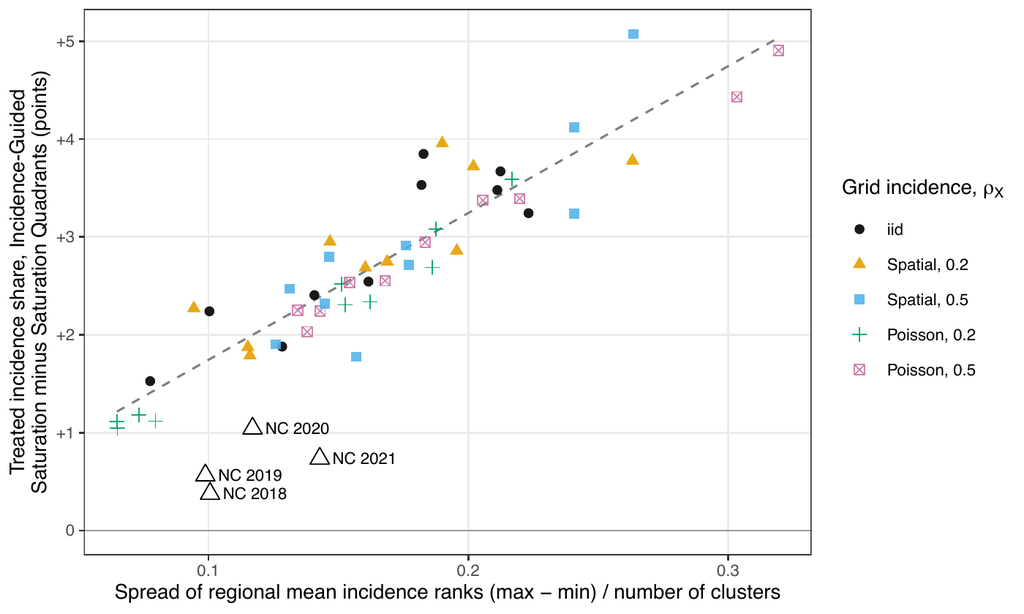

Each point is one simulated grid incidence surface, plotting the spread of the regions’ mean incidence ranks against the extra treated share of incidence from incidence guidance over random-order saturation. NC’s four planning years (open triangles) sit at the low-spread end and below the grid trend.

## Backup · At larger effects Isolation Buffer catches up under controls only

- Grid, controls only: Incidence-Guided Saturation’s advantage narrows as $\tau$ grows
- At $\tau = 2$, Isolation Buffer and Incidence-Guided Saturation are level (MSE 0.160 and 0.160); at $\tau = 3$ Isolation Buffer is lower (0.160 vs 0.182)
- Most designs carry error in estimating $\rho$ into $\hat\tau$ in proportion to $\tau$; Isolation Buffer largely avoids this since no treated cluster has a treated neighbor
- Isolation Buffer is still 3.8 times SRS’s error under both arms and treats fewer clusters